# STAT 545A Homework 6

### Plotting simple figures using `ggplot2`

We create one additional container to hold data for ploting purposes and to perform other applications on our data without altering the main data. Doing so we demonstrate the inheritance structure in our coding scheme.

```r
plot.en <- new.env(parent = main.en)
```

We require the following packages.

```r
require(plyr)
```

```r
require(ggplot2)
```

Let us plot our first figure which depicts the education level per gender

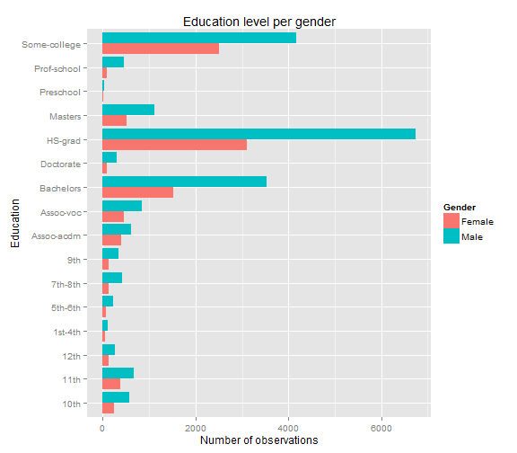

```r
evalq({
    edulevelPergender <- ddply(.data = adult.data, .variables = ~educationNum +
        sex, .fun = function(x) {
        count <- nrow(x)
        return(data.frame(count))
    })
    plotbar <- ggplot(adult.data, aes(x = factor(education), fill = factor(sex)))
    plotbar <- plotbar + ggtitle("Education level per gender")
    plotbar <- plotbar + geom_bar(position = "dodge") + coord_flip()
    plotbar <- plotbar + xlab("Education") + ylab("Number of observations")
    plotbar <- plotbar + scale_fill_discrete(name = "Gender")
    plotbar
}, envir = plot.en)
```

We see that the above figure does not represent the ratio of each gender with the level of education in the dataset for that particular gender. Therefore, we use proportions of each gender in the dataset according to their level of education and re-plot the results.

[output not shown]

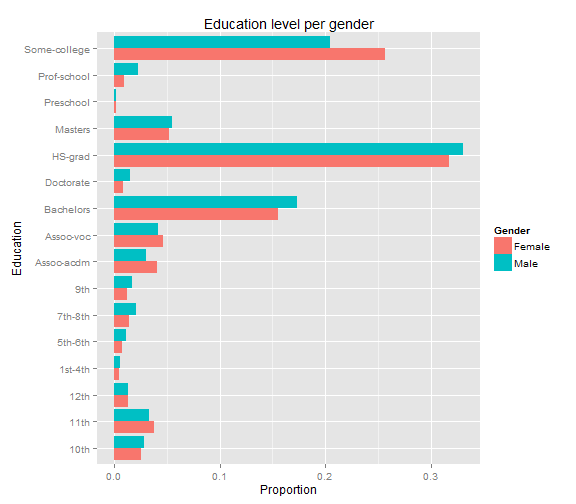

```r
evalq({
    nPerSex <- count(df = adult.data, ~sex)
    adult.data.modified <- ddply(adult.data, ~education + sex, summarise, proportion = length(education))
    adult.data.modified$proportion = ifelse(test = adult.data.modified$sex ==
        "Male", yes = adult.data.modified$proportion/nPerSex$freq[2], no = adult.data.modified$proportion/nPerSex$freq[1])
    plotbarprop <- ggplot(adult.data.modified, aes(x = factor(education), y = proportion,
        fill = factor(sex)))
    plotbarprop <- plotbarprop + ggtitle("Education level per gender")
    plotbarprop <- plotbarprop + geom_bar(position = "dodge") + coord_flip()
    plotbarprop <- plotbarprop + xlab("Education") + ylab("Proportion")
    plotbarprop <- plotbarprop + scale_fill_discrete(name = "Gender")
    plotbarprop
}, envir = plot.en)
```

Now, we observe similar proportions for each gender with the level of education. In fact, females are more educated in some levels such as at 11th grade. This piece of information did not reveal to us in our previous figure.

We use boxplot that provides a graphical overview of how the observations of a particular variable, age in our case, are distributed per gender.

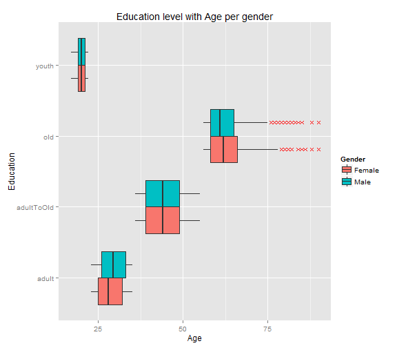

```r
evalq({
    plotbox <- ggplot(adult.data) + aes(x = factor(agedesc), y = age)
    plotbox <- plotbox + geom_boxplot(aes(fill = sex), outlier.colour = "red",
        outlier.shape = 4)
    plotbox <- plotbox + ggtitle("Education level with Age per gender")
    plotbox <- plotbox + xlab("Education") + ylab("Age")
    plotbox <- plotbox + scale_fill_discrete(name = "Gender") + coord_flip()
    plotbox
}, envir = plot.en)
```

Here we plot education level with specific age intervals.

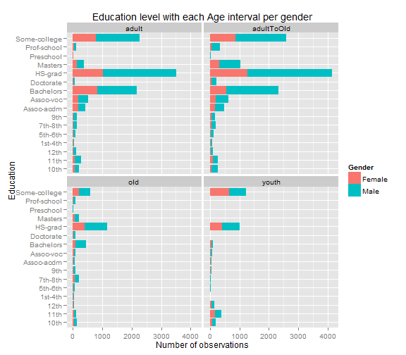

```r
evalq({
    p1 <- ggplot(adult.data) + aes(education, fill = factor(sex))
    p1 <- p1 + ggtitle("Education level with each Age interval per gender")
    p1 <- p1 + geom_bar() + xlab("Education") + ylab("Number of observations")
    p1 <- p1 + scale_fill_discrete(name = "Gender") + coord_flip()
    p1 <- p1 + facet_wrap(~agedesc)
    p1
}, envir = plot.en)
```

Plotting the number of educated people based on their ethnicity.

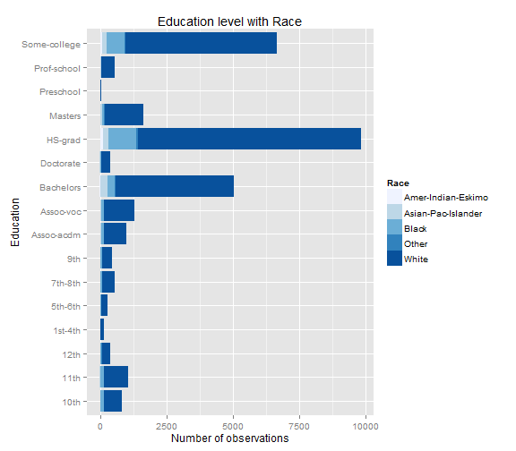

```r
evalq({
    p2 <- ggplot(adult.data) + aes(education, fill = race)
    p2 <- p2 + ggtitle("Education level with Race")
    p2 <- p2 + geom_bar() + xlab("Education") + ylab("Number of observations")
    p2 <- p2 + scale_fill_brewer("Race") + coord_flip()
    p2
}, envir = plot.en)
```

Gradient colors are not a convenient solution in plotting the above figure. We plot the status of relationships with level of educations and we use `palette` option:

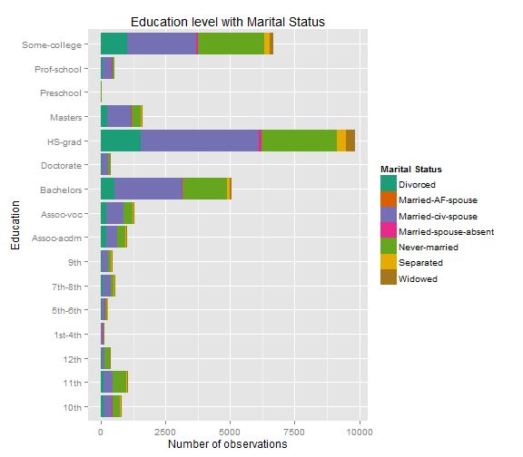

```r
evalq({
    p3 <- ggplot(adult.data) + aes(education, fill = maritalStatus)
    p3 <- p3 + ggtitle("Education level with Marital Status")
    p3 <- p3 + geom_bar() + xlab("Education") + ylab("Number of observations")
    p3 <- p3 + scale_fill_brewer("Marital Status", palette = "Dark2") + coord_flip()
    p3
}, envir = plot.en)
```

Exploring the type of employment with level of educations:

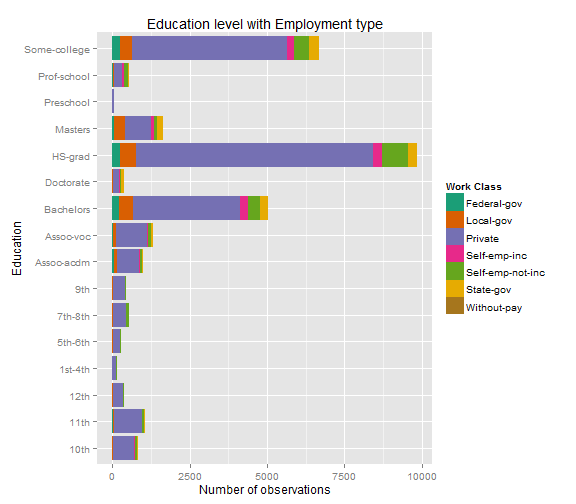

```r
evalq({
    p4 <- ggplot(adult.data) + aes(education, fill = workclass)
    p4 <- p4 + ggtitle("Education level with Employment type")
    p4 <- p4 + geom_bar() + xlab("Education") + ylab("Number of observations")
    p4 <- p4 + scale_fill_brewer("Work Class", palette = "Dark2") + coord_flip()
    p4
}, envir = plot.en)
```

`gridExtra` is an interesting package that puts several figures onto one panel. As an example:

```r
require(gridExtra)
```

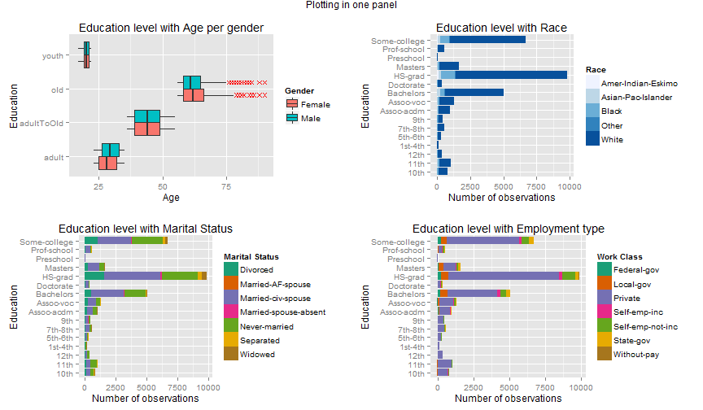

```r
evalq({
    grid.arrange(plotbox, p2, p3, p4, ncol = 2, main = "Plotting in one panel")
}, envir = plot.en)
```

### Plotting world map using `ggplot2`

We load the following packages.

```r
require(ggmap)
```

```r
require(mapproj)
```

We copy map data into plot.en container

```r
evalq({
    map.world <- map_data(map = "world")
}, envir = plot.en)
```

Let us draw a map using ggplot2. We first note that the countries in adult data need to be mapped with regions in the map data. Therefore, several issues need to be handled properly:

- some countries in our data does not exist in map data, for example Scotland. We merge these countries with their closest neighbours.
- names of countries are different or abbreviated in both data, for example USA is used in map data and it is renamed to United-States in adult data.
- countries in adult data are misspelled or are not complete, for example in our data there is a country named by south but we do not have enough information to guess whether it is the south korea or the south africa. Another example, the country `Outlying-US(Guam-USVI-etc)` does not have any equivalent with map data.

```r
evalq({
    adult.data$nativeCountry <- gsub("(Outlying-US\\(Guam-USVI-etc\\))", NA,
        adult.data$nativeCountry)
    adult.data$nativeCountry <- gsub("England", "UK", adult.data$nativeCountry)
    adult.data$nativeCountry <- gsub("Scotland", "UK", adult.data$nativeCountry)
    adult.data$nativeCountry <- gsub("Hong", "China", adult.data$nativeCountry)
    adult.data$nativeCountry <- gsub("Taiwan", "China", adult.data$nativeCountry)
    adult.data$nativeCountry <- gsub("Trinadad&Tobago", "Tobago", adult.data$nativeCountry)
    adult.data$nativeCountry <- gsub("United-States", "USA", adult.data$nativeCountry)
    adult.data$nativeCountry <- gsub("Puerto-Rico", "Puerto Rico", adult.data$nativeCountry)
    adult.data$nativeCountry <- gsub("Holand-Netherlands", "Netherlands", adult.data$nativeCountry)
    adult.data$nativeCountry <- gsub("El-Salvador", "El Salvador", adult.data$nativeCountry)
    adult.data$nativeCountry <- gsub("Dominican-Republic", "Dominican Republic",
        adult.data$nativeCountry)
    adult.data$nativeCountry <- gsub("Columbia", "Colombia", adult.data$nativeCountry)
    adult.data$nativeCountry <- gsub("South", "South Korea", adult.data$nativeCountry)
    adult.data <- na.omit(adult.data)
}, plot.en)
```

After we address the above shortcomings, let's begin to plot our first world map.

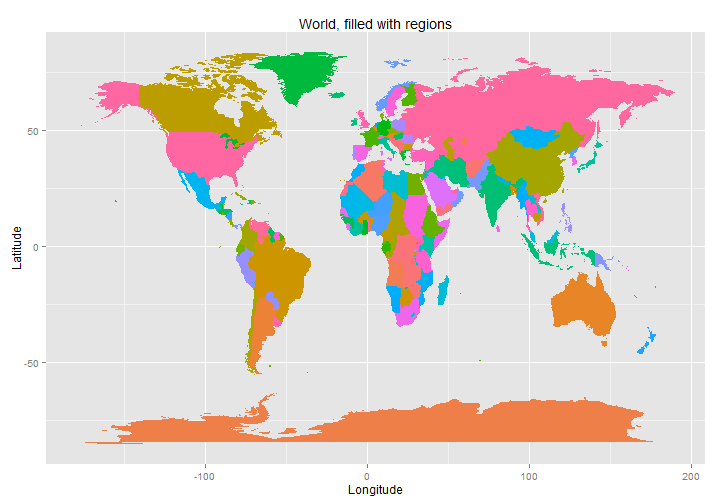

```r
evalq({
    plot <- ggplot(map.world, aes(x = long, y = lat, group = group, fill = region))
    plot <- plot + ggtitle("World, filled with regions")
    plot <- plot + geom_polygon() + theme(legend.position = "none")
    plot <- plot + xlab("Longitude") + ylab("Latitude")
    plot
}, envir = plot.en)
```

Interestingly, we can also represent the filled countries that are only recorded in adult data as follows:

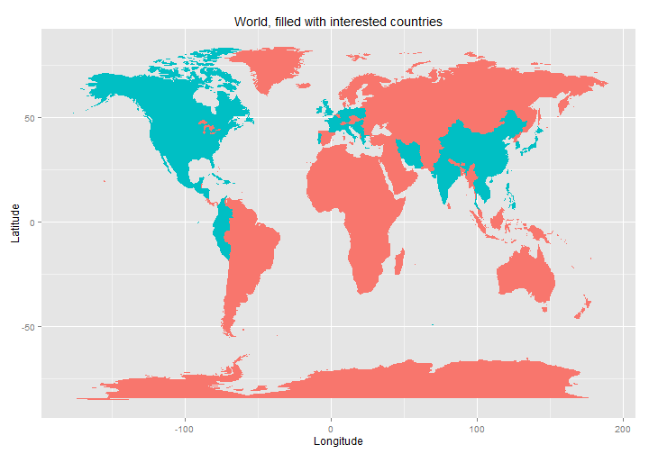

```r
evalq({
    map.world$availableCountry <- ifelse(test = map.world$region %in% adult.data$nativeCountry,
        yes = "yes", no = "no")

    plot <- ggplot(map.world, aes(x = long, y = lat, group = group, fill = availableCountry))
    plot <- plot + ggtitle("World, filled with interested countries")
    plot <- plot + geom_polygon() + theme(legend.position = "none")
    plot <- plot + xlab("Longitude") + ylab("Latitude")
    plot
}, envir = plot.en)
```

Let us perform more fancy work by plotting the world map according to the median age per country.

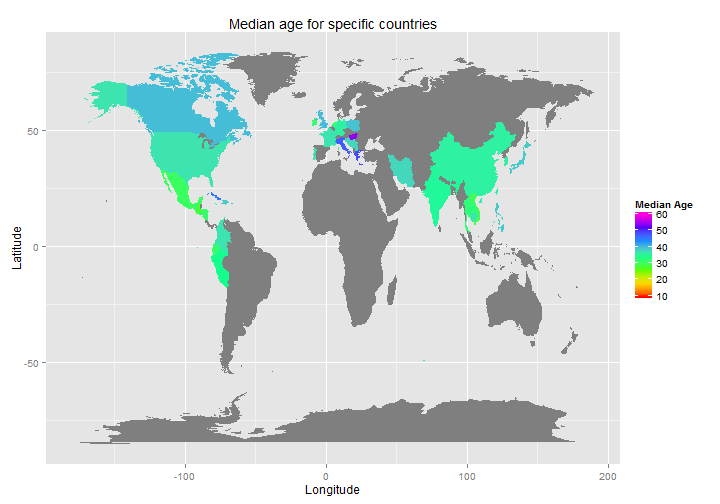

```r
evalq({
    tmp.df <- ddply(adult.data, ~nativeCountry, summarise, medianAge = median(age),
        meanAge = mean(age))
    map.world <- merge(x = map.world, y = tmp.df, by.x = "region", by.y = "nativeCountry",
        all = TRUE)
    map.world$medianAge[is.na(map.world$medianAge)] <- 0  # other countries median
    # are set to 0
    map.world$meanAge[is.na(map.world$meanAge)] <- 0  # other countries mean
    # are set to 0
    map.world <- arrange(map.world, order)  # We need to sort the map.world data
    # according to the order variable for the purpose of plotting
    plot <- ggplot(map.world, aes(x = long, y = lat, group = group, fill = medianAge))
    plot <- plot + ggtitle("Median age for specific countries")
    plot <- plot + geom_polygon() + scale_fill_gradientn("Median Age", colours = rainbow(7),
        limits = c(10, 60))
    plot <- plot + xlab("Longitude") + ylab("Latitude")
    plot
}, envir = plot.en)
```

### Plotting dendrogram using `ggplot2`

In our dataset, we identify some kind of relationships or correlations between the observations of continous variables. Let us explore the relationships between numerical variables using a tree-like structure known as a `dendrogram`. For this, we need to load the following packages:

```r
require(grid)
require(ggdendro)
```

We first identify the numerical variables and then perform correlation between them. Afterwards, we apply hclust function to the results in order to create an object with hierarchical structure that will be used to plot dendrogram.

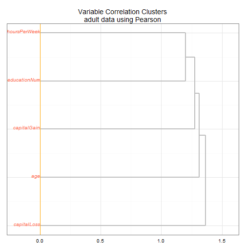

```r
evalq({
    numerics <- c(1, 5, 11:13)
    cr <- cor(x = adult.data[numerics], use = "pairwise", method = "pearson")
    hc <- hclust(dist(cr), method = "average")
    ddata <- dendro_data(hc)

    plot <- ggplot() + geom_segment(data = segment(ddata), aes_string(x = "x",
        y = "y", xend = "xend", yend = "yend"), colour = "grey", lwd = 1)
    plot <- plot + geom_text(data = label(ddata), aes_string(x = "x", y = "y",
        label = "label"), fontface = 3, colour = "tomato", cex = 3.5, hjust = 1,
        vjust = 0, angle = 0)
    plot <- plot + scale_y_continuous(expand = c(0.2, 0))
    plot <- plot + labs(title = "Variable Correlation Clusters\nadult data using Pearson")
    plot <- plot + theme_bw() + theme(axis.ticks = element_blank(), axis.text.y = element_blank())
    plot <- plot + geom_hline(data = segment(ddata), xintercept = "x", colour = "orange") +
        ylab(NULL) + xlab(NULL)
    plot <- plot + coord_flip()
    plot
}, envir = plot.en)
```

Although, the above correlation defines the relationships between the numerical data, this does not provide true information because much of our data are missing and replaced by 0. But to illustrate the correlation, we plot the relationship between hours per week with the education level ignoring the whether information is accurate or not.

[figure not shown]

```r
evalq({
    plot <- ggplot(data = adult.data, aes(x = hoursPerWeek, y = educationNum,
        colour = hoursPerWeek))
    plot <- plot + geom_point(alpha = 1/10)
    plot <- plot + ggtitle("Hours per Week vs Level of Education")
    plot <- plot + stat_smooth(method = "lm", se = FALSE, colour = "red", size = 1)
    plot <- plot + xlab("Education Level") + ylab("Hours per Week")
    plot <- plot + theme(legend.position = "none")
    plot
}, envir = plot.en)
```

> Thank you Jenny for being the person who taught us how to appreciate the art of R language. We had a great time last six weeks.